# R Notebook

# Data Types

Resource and basis: - https://r4ds.had.co.nz/strings.html - https://r4ds.had.co.nz/factors.html - https://r4ds.had.co.nz/dates-and-times.html - https://r4ds.had.co.nz/vectors.html

```r
library(tidyverse)
```

# Strings

## String basics

```r
string1 <- "This is a string"
string2 <- 'If I want to include a "quote" inside a string, I use single quotes'
```

```r
double_quote <- "\"" # or '"'
single_quote <- '\'' # or "'"
```

```r
x <- "\u00b5"
x
```

```
[1] "µ"
```

### String length

```r
str_length(c("a", "R for data science", NA))
```

```
[1]  1 18 NA
```

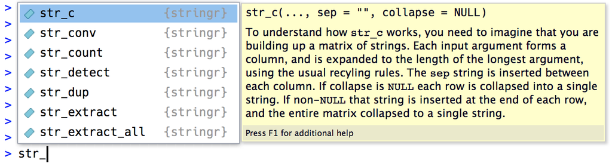

### Combining strings

```r
test<- str_c("x", "y", "z")
test
```

```
[1] "xyz"
```

```r
str_c("x", "y", sep = ", ")
```

```
[1] "x, y"
```

### Subsetting strings

```r
x <- c("Apple", "Banana", "Pear")
str_sub(x, 1, 3)
```

```
[1] "App" "Ban" "Pea"
```

```r
# negative numbers count backwards from end
str_sub(x, -3, -1)
```

```
[1] "ple" "ana" "ear"
```

## Matching patterns with regular expressions

### Basic matches

```r
x <- c("apple", "banana", "pear")
str_view(x, "an")
```

[interactive chart not shown]

```r
str_view(x, ".a.")
```

[interactive chart not shown]

```r
# To create the regular expression, we need \\
dot <- "\\."

# But the expression itself only contains one:
writeLines(dot)
```

```
\.
```

```r
# And this tells R to look for an explicit .
str_view(c("abc", "a.c", "bef"), "a\\.c")
```

[interactive chart not shown]

### Anchors

- `^` to match the start of the string.
- `$` to match the end of the string.

```r
x <- c("apple", "banana", "pear")
str_view(x, "^a")
```

[interactive chart not shown]

```r
str_view(x, "a$")
```

[interactive chart not shown]

Complete String

```r
x <- c("apple pie", "apple", "apple cake")
str_view(x, "apple")
```

[interactive chart not shown]

```r
str_view(x, "^apple$")
```

[interactive chart not shown]

### Character classes

- `\d`: matches any digit.
- `\s`: matches any whitespace (e.g. space, tab, newline).
- `[abc]`: matches a, b, or c.
- `[^abc]`: matches anything except a, b, or c.

### Repetition

- `?`: 0 or 1
- `+`: 1 or more
- `*`: 0 or more

```r
x <- "1888 is the longest year in Roman numerals: MDCCCLXXXVIII"
str_view(x, "CC?")
```

[interactive chart not shown]

```r
str_view(x, "CC+")
```

[interactive chart not shown]

```r
str_view(x, 'C[LX]+')
```

[interactive chart not shown]

- `{n}`: exactly n
- `{n,}`: n or more
- `{,m}`: at most m
- `{n,m}`: between n and m

```r
str_view(x, "C{2}")
```

[interactive chart not shown]

```r
str_view(x, "C{2,}")
```

[interactive chart not shown]

```r
str_view(x, "C{2,3}")
```

[interactive chart not shown]

## Tools

### Detect matches

```r
x <- c("apple", "banana", "pear")
str_detect(x, "e")
```

```r
words[str_detect(words, "x$")]
str_subset(words, "x$")
```

```r
df <- tibble(
  word = words,
  i = seq_along(word)
)
df %>%
  filter(str_detect(word, "x$"))
```

```r
x <- c("apple", "banana", "pear")
str_count(x, "a")

# On average, how many vowels per word?
mean(str_count(words, "[aeiou]"))
```

```r
df %>%
  mutate(
    vowels = str_count(word, "[aeiou]"),
    consonants = str_count(word, "[^aeiou]")
  )
```

### Extract matches

```r
length(sentences)
head(sentences)
```

```r
colours <- c("red", "orange", "yellow", "green", "blue", "purple")
colour_match <- str_c(colours, collapse = "|")
colour_match
```

```r
has_colour <- str_subset(sentences, colour_match)
matches <- str_extract(has_colour, colour_match)
head(matches)
```

### Replacing matches

```r
x <- c("apple", "pear", "banana")
str_replace(x, "[aeiou]", "-")
str_replace_all(x, "[aeiou]", "-")
```

```r
x <- c("1 house", "2 cars", "3 people")
str_replace_all(x, c("1" = "one", "2" = "two", "3" = "three"))
```

### Splitting

```r
sentences %>%
  head(5) %>%
  str_split(" ")
```

# Factors

## Creating factors

1. There are only twelve possible months, and there’s nothing saving you from typos
2. It doesn’t sort in a useful way

```r
x1 <- c("Dec", "Apr", "Jan", "Mar")
```

```r
x2 <- c("Dec", "Apr", "Jam", "Mar")
```

```r
sort(x1)
```

```
[1] "Apr" "Dec" "Jan" "Mar"
```

```r
month_levels <- c(
  "Jan", "Feb", "Mar", "Apr", "May", "Jun",
  "Jul", "Aug", "Sep", "Oct", "Nov", "Dec"
)
```

```r
y1 <- factor(x1, levels = month_levels)
y1
```

```
[1] Dec Apr Jan Mar
Levels: Jan Feb Mar Apr May Jun Jul Aug Sep Oct Nov Dec
```

```r
sort(y1)
```

```
[1] Jan Mar Apr Dec
Levels: Jan Feb Mar Apr May Jun Jul Aug Sep Oct Nov Dec
```

## General Social Survey

```r
gss_cat
```

| year | marital | age | race | rincome | partyid | relig | denom | tvhours |
| --- | --- | --- | --- | --- | --- | --- | --- | --- |
| 2000 | Never married | 26 | White | $8000 to 9999 | Ind,near rep | Protestant | Southern baptist | 12 |
| 2000 | Divorced | 48 | White | $8000 to 9999 | Not str republican | Protestant | Baptist-dk which | NA |
| 2000 | Widowed | 67 | White | Not applicable | Independent | Protestant | No denomination | 2 |
| 2000 | Never married | 39 | White | Not applicable | Ind,near rep | Orthodox-christian | Not applicable | 4 |
| 2000 | Divorced | 25 | White | Not applicable | Not str democrat | None | Not applicable | 1 |
| 2000 | Married | 25 | White | $20000 - 24999 | Strong democrat | Protestant | Southern baptist | NA |
| 2000 | Never married | 36 | White | $25000 or more | Not str republican | Christian | Not applicable | 3 |
| 2000 | Divorced | 44 | White | $7000 to 7999 | Ind,near dem | Protestant | Lutheran-mo synod | NA |
| 2000 | Married | 44 | White | $25000 or more | Not str democrat | Protestant | Other | 0 |
| 2000 | Married | 47 | White | $25000 or more | Strong republican | Protestant | Southern baptist | 3 |

[output cut: 990 more lines]

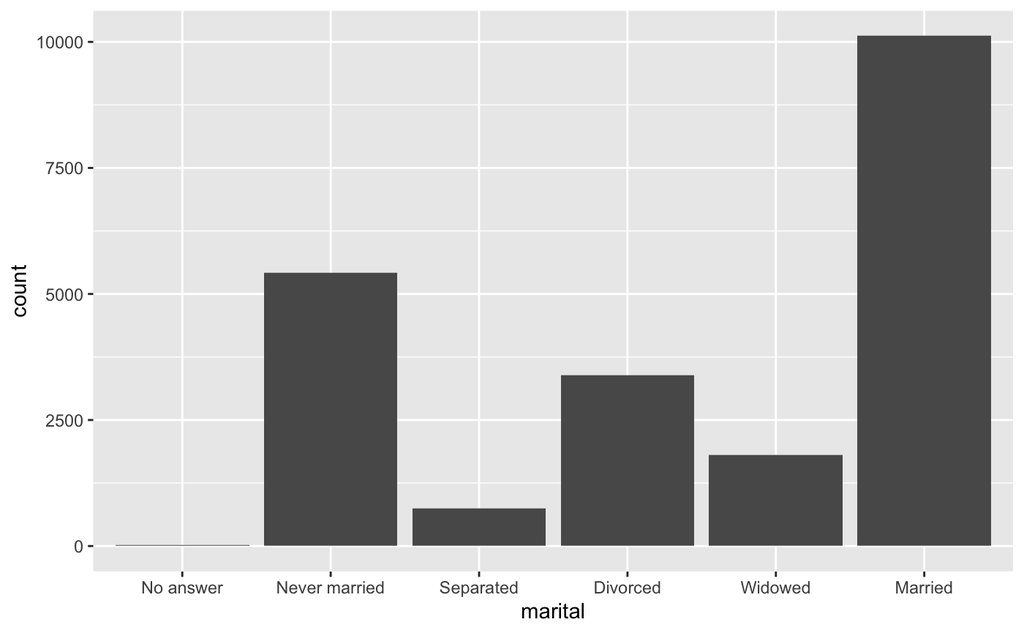

```r
ggplot(gss_cat, aes(marital)) +
  geom_bar() +
  scale_x_discrete(drop = FALSE)
```

## Modifying factor order

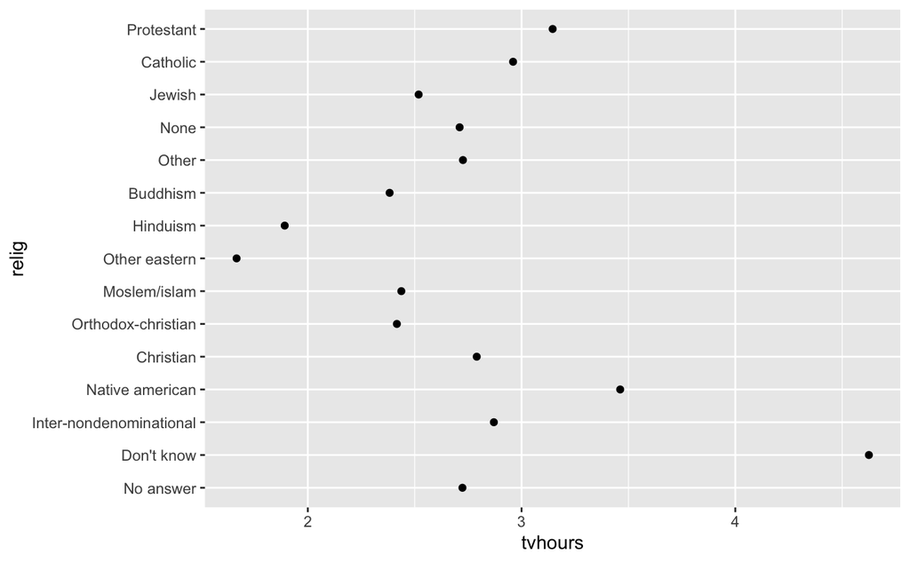

```r
relig_summary <- gss_cat %>%
  group_by(relig) %>%
  summarise(
    age = mean(age, na.rm = TRUE),
    tvhours = mean(tvhours, na.rm = TRUE),
    n = n()
  )

ggplot(relig_summary, aes(tvhours, relig)) + geom_point()
```

- `f`, the factor whose levels you want to modify.
- `x`, a numeric vector that you want to use to reorder the levels.
- Optionally, `fun`, a function that’s used if there are multiple values of `x` for each value of `f`. The default value is `median`.

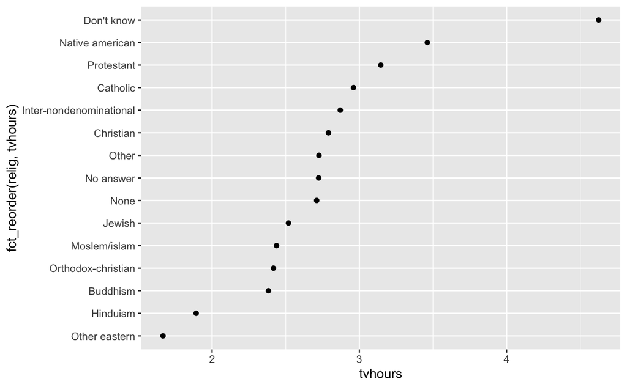

```r
ggplot(relig_summary, aes(tvhours, fct_reorder(relig, tvhours))) +
  geom_point()
```

```r
relig_summary %>%
  mutate(relig = fct_reorder(relig, tvhours)) %>%
  ggplot(aes(tvhours, relig)) +
    geom_point()
```

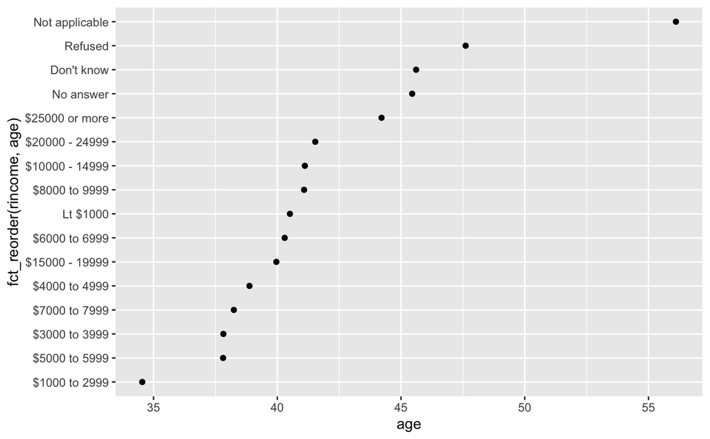

```r
rincome_summary <- gss_cat %>%
  group_by(rincome) %>%
  summarise(
    age = mean(age, na.rm = TRUE),
    tvhours = mean(tvhours, na.rm = TRUE),
    n = n()
  )

ggplot(rincome_summary, aes(age, fct_reorder(rincome, age))) + geom_point()
```

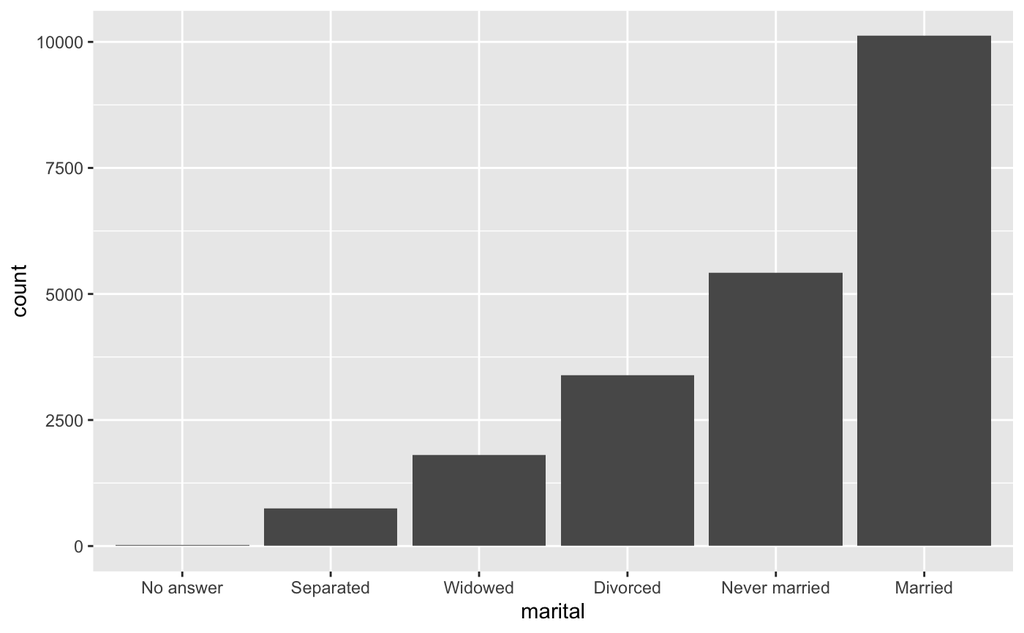

```r
gss_cat %>%
  mutate(marital = marital %>%
           fct_infreq() %>%
           fct_rev()) %>%
  ggplot(aes(marital)) +
    geom_bar()
```

## Modifying factor levels

```r
gss_cat %>% count(partyid)
```

| partyid | n |
| --- | --- |
| No answer | 154 |
| Don't know | 1 |
| Other party | 393 |
| Strong republican | 2314 |
| Not str republican | 3032 |
| Ind,near rep | 1791 |
| Independent | 4119 |
| Ind,near dem | 2499 |
| Not str democrat | 3690 |
| Strong democrat | 3490 |

```r
gss_cat %>%
  mutate(partyid = fct_recode(partyid,
    "Republican, strong"    = "Strong republican",
    "Republican, weak"      = "Not str republican",
    "Independent, near rep" = "Ind,near rep",
    "Independent, near dem" = "Ind,near dem",
    "Democrat, weak"        = "Not str democrat",
    "Democrat, strong"      = "Strong democrat"
  )) %>%
  count(partyid)
```

| partyid | n |
| --- | --- |
| No answer | 154 |
| Don't know | 1 |
| Other party | 393 |
| Republican, strong | 2314 |
| Republican, weak | 3032 |
| Independent, near rep | 1791 |
| Independent | 4119 |
| Independent, near dem | 2499 |
| Democrat, weak | 3690 |
| Democrat, strong | 3490 |

```r
gss_cat %>%
  mutate(partyid = fct_recode(partyid,
    "Republican, strong"    = "Strong republican",
    "Republican, weak"      = "Not str republican",
    "Independent, near rep" = "Ind,near rep",
    "Independent, near dem" = "Ind,near dem",
    "Democrat, weak"        = "Not str democrat",
    "Democrat, strong"      = "Strong democrat",
    "Other"                 = "No answer",
    "Other"                 = "Don't know",
    "Other"                 = "Other party"
  )) %>%
  count(partyid)
```

| partyid | n |
| --- | --- |
| Other | 548 |
| Republican, strong | 2314 |
| Republican, weak | 3032 |
| Independent, near rep | 1791 |
| Independent | 4119 |
| Independent, near dem | 2499 |
| Democrat, weak | 3690 |
| Democrat, strong | 3490 |

# Dates and times

- Does every year have 365 days?
- Does every day have 24 hours?
- Does every minute have 60 seconds?

```r
library(lubridate)
library(nycflights13)
```

## Creating date/times

- A **date**. Tibbles print this as `<date>`.
- A **time** within a day. Tibbles print this as `<time>`.
- A **date-time** is a date plus a time: it uniquely identifies an instant in time (typically to the nearest second). Tibbles print this as `<dttm>`.

```r
today()
now()
```

- From a string.
- From individual date-time components.
- From an existing date/time object.

### From strings

```r
ymd("2017-01-31")
mdy("January 31st, 2017")
dmy("31-Jan-2017")
```

```r
ymd(20170131)
```

```r
ymd_hms("2017-01-31 20:11:59")
mdy_hm("01/31/2017 08:01")
```

### From individual components

```r
flights %>%
  select(year, month, day, hour, minute)
```

```r
flights %>%
  select(year, month, day, hour, minute) %>%
  mutate(departure = make_datetime(year, month, day, hour, minute))
```

```r
make_datetime_100 <- function(year, month, day, time) {
  make_datetime(year, month, day, time %/% 100, time %% 100)
}

flights_dt <- flights %>%
  filter(!is.na(dep_time), !is.na(arr_time)) %>%
  mutate(
    dep_time = make_datetime_100(year, month, day, dep_time),
    arr_time = make_datetime_100(year, month, day, arr_time),
    sched_dep_time = make_datetime_100(year, month, day, sched_dep_time),
    sched_arr_time = make_datetime_100(year, month, day, sched_arr_time)
  ) %>%
  select(origin, dest, ends_with("delay"), ends_with("time"))

flights_dt
```

```r
flights_dt %>%
  ggplot(aes(dep_time)) +
  geom_freqpoly(binwidth = 86400) # 86400 seconds = 1 day
```

[output not shown]

```r
flights_dt %>%
  filter(dep_time < ymd(20130102)) %>%
  ggplot(aes(dep_time)) +
  geom_freqpoly(binwidth = 600) # 600 s = 10 minutes
```

[output not shown]

## Date-time components

```r
datetime <- ymd_hms("2016-07-08 12:34:56")

year(datetime)
month(datetime)
mday(datetime)

yday(datetime)
wday(datetime)
```

```r
month(datetime, label = TRUE)
wday(datetime, label = TRUE, abbr = FALSE)
```

```r
flights_dt %>%
  mutate(minute = minute(dep_time)) %>%
  group_by(minute) %>%
  summarise(
    avg_delay = mean(arr_delay, na.rm = TRUE),
    n = n()) %>%
  ggplot(aes(minute, avg_delay)) +
    geom_line()
```

### Setting components

```r
(datetime <- ymd_hms("2016-07-08 12:34:56"))

year(datetime) <- 2020
datetime
month(datetime) <- 01
datetime
hour(datetime) <- hour(datetime) + 1
datetime
```

## Time spans

- **durations**, which represent an exact number of seconds.
- **periods**, which represent human units like weeks and months.

### Durations

```r
# How old is South Africa?
sa_age <- today() - ymd(19940427)
sa_age
```

```r
as.duration(sa_age)
```

```r
2 * dyears(1)
dyears(1) + dweeks(12) + dhours(15)
```

### Periods

```r
10 * (months(6) + days(1))
days(50) + hours(25) + minutes(2)
```

```r
# A leap year
ymd("2016-01-01") + dyears(1)
ymd("2016-01-01") + years(1)
```

Reading:

R4ds: Chapters 14, 15, 16, 20

- https://r4ds.had.co.nz/strings.html
- https://r4ds.had.co.nz/factors.html
- https://r4ds.had.co.nz/dates-and-times.html
- https://r4ds.had.co.nz/vectors.html